# 04: Gating

← Prev: Unmixing & Transformation Next: Dimensionality Reduction →

```r
library(flowCore)
library(flowWorkspace)
library(openCyto)
library(tidyverse)
```

```r
gs <- load_gs("data/processed/PBMC_gs_transformed")
```

Gating is sequential — each gate is applied within the parent population from the previous step. The order here is: all events → remove debris → remove doublets → exclude dead cells → gate population of interest. Every downstream number is a direct consequence of where these gates are drawn.

## Scatter gate

Start with FSC-A vs SSC-A to exclude debris and retain intact cells. FSC-A (area) reflects cell size; SSC-A reflects internal complexity. Debris falls at very low FSC; lymphocytes cluster at low-to-mid FSC with low SSC; monocytes and granulocytes sit higher.

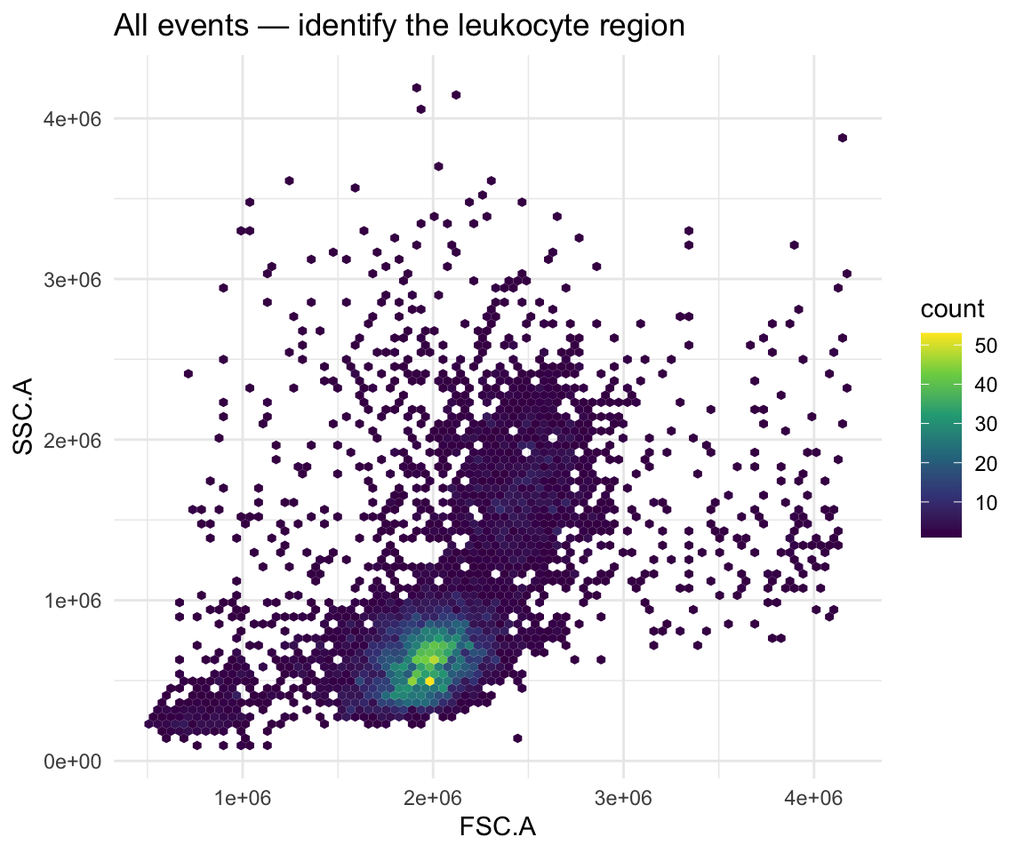

```r
df_all <- get_pop_df(gs, "root")

ggplot(df_all, aes(x = FSC.A, y = SSC.A)) +
  geom_hex(bins = 80) +
  scale_fill_viridis_c() +
  theme_minimal(base_size = 11) +
  labs(title = "All events — identify the leukocyte region")
```

```r
scatter_gate <- rectangleGate(
  filterId = "leukocytes",
  "FSC-A"  = c(750000, 3000000),
  "SSC-A"  = c(50000, 2500000)
)
gs_pop_add(gs, scatter_gate, parent = "root")
```

```
## [1] 2
```

```r
recompute(gs)
```

```
## done!
```

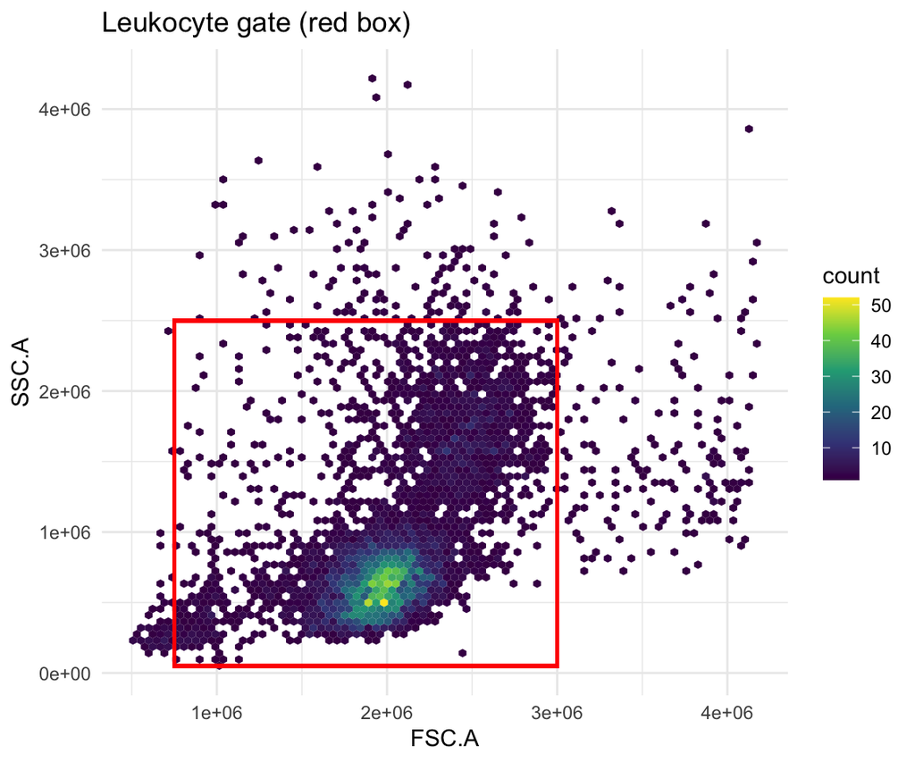

```r
ggplot(df_all, aes(x = FSC.A, y = SSC.A)) +
  geom_hex(bins = 80) +
  scale_fill_viridis_c() +
  geom_rect(aes(xmin = 750000, xmax = 3000000, ymin = 50000, ymax = 2500000),
            fill = NA, color = "red", linewidth = 0.8, inherit.aes = FALSE) +
  theme_minimal(base_size = 11) +
  labs(title = "Leukocyte gate (red box)")
```

## Singlet gate

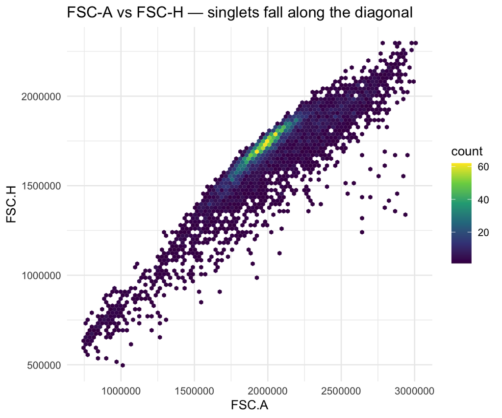

```r
df_leuko <- get_pop_df(gs, "leukocytes")

ggplot(df_leuko, aes(x = FSC.A, y = FSC.H)) +
  geom_hex(bins = 80) +
  scale_fill_viridis_c() +
  theme_minimal(base_size = 11) +
  labs(title = "FSC-A vs FSC-H — singlets fall along the diagonal")
```

```r
singlet_gate <- polygonGate(
  filterId = "singlets",
  .gate = matrix(
    c(
      750000,  100000,
      750000, 2100000,
     3000000, 2700000,
     3000000, 1500000
    ),
    ncol = 2, byrow = TRUE,
    dimnames = list(NULL, c("FSC-A", "FSC-H"))
  )
)
gs_pop_add(gs, singlet_gate, parent = "leukocytes")
```

```
## [1] 3
```

```r
recompute(gs)
```

```
## done!
```

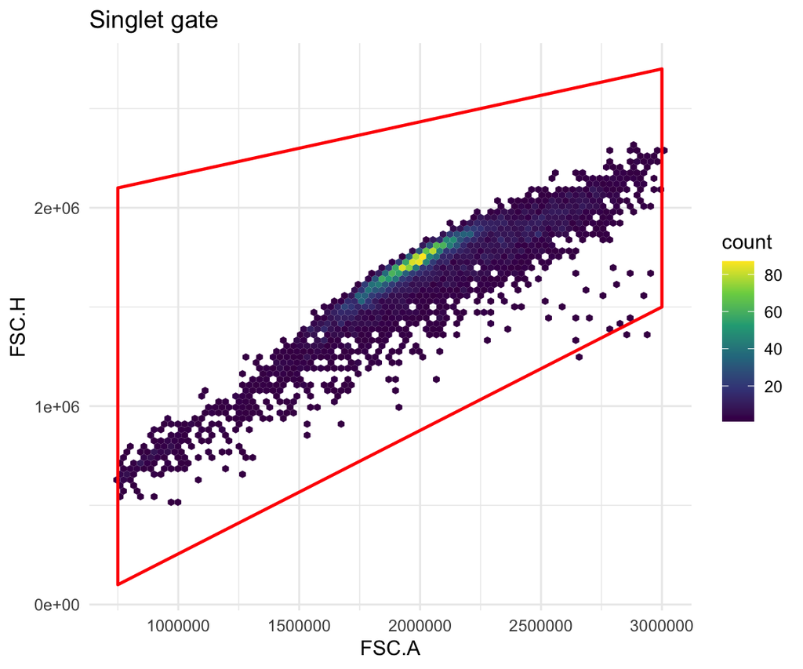

```r
gate_poly <- data.frame(
  FSC.A = c( 750000,  750000, 3000000, 3000000),
  FSC.H = c( 100000, 2100000, 2700000, 1500000)
)
ggplot(df_leuko, aes(x = FSC.A, y = FSC.H)) +
  geom_hex(bins = 80) +
  scale_fill_viridis_c() +
  geom_polygon(data = gate_poly, aes(x = FSC.A, y = FSC.H),
               fill = NA, color = "red", linewidth = 0.8) +
  theme_minimal(base_size = 11) +
  labs(title = "Singlet gate")
```

> **Automatic singlet gating:** `flowStats::singletGate()` fits the diagonal automatically from the data, avoiding manual vertex selection.

## Live cell gate

The viability dye (PO_DCM) enters dead cells and stains them brightly. Live cells are dim or negative. Gate on `Viability` low to retain only live cells:

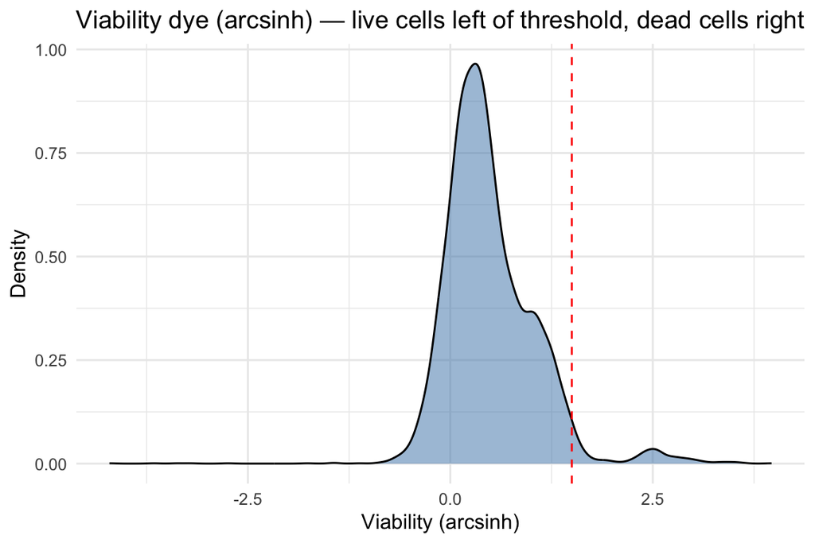

```r
df_sing <- get_pop_df(gs, "singlets")

ggplot(df_sing, aes(x = Viability)) +
  geom_density(fill = "steelblue", alpha = 0.5) +
  geom_vline(xintercept = 1.5, color = "red", linetype = "dashed") +
  theme_minimal(base_size = 11) +
  labs(title = "Viability dye (arcsinh) — live cells left of threshold, dead cells right",
       x = "Viability (arcsinh)", y = "Density")
```

```r
live_gate <- rectangleGate(
  filterId  = "live",
  "Viability" = c(-Inf, 1.5)
)
gs_pop_add(gs, live_gate, parent = "singlets")
```

```
## [1] 4
```

```r
recompute(gs)
```

```
## done!
```

## Choosing channels for your population gate

The channels you gate on should correspond to the markers that define your population of interest. There is no universal answer — it depends entirely on your panel design.

**Start from biology, not from the data.** Before looking at any plots, you should already know which markers your population expresses. If you are gating CD8+ T cells, you need the channel your CD8 antibody is on. Looking at plots first and drawing gates around whatever cluster looks interesting is not a sound approach.

**Use markers that clearly separate your population.** The best gate is one where your population forms a distinct cluster with visible empty space between it and everything else.

**Check consistency across samples.** In a multi-sample experiment, scan all samples after setting values to confirm the gate captures the same population in each one. If the population shifts between samples due to staining variability, tissue differences, or batch effects, a fixed gate will be systematically wrong for some of them.

**Back-gate to verify.** After gating, plot the gated population back onto FSC vs SSC. If those cells don’t fall where you’d expect that cell type to sit, the gate is probably capturing the wrong thing.

## T cell gate

CD3 marks all T cells. Its density plot after transformation should show a clear bimodal distribution: CD3-negative cells (B cells, monocytes, NK cells) and CD3-positive T cells.

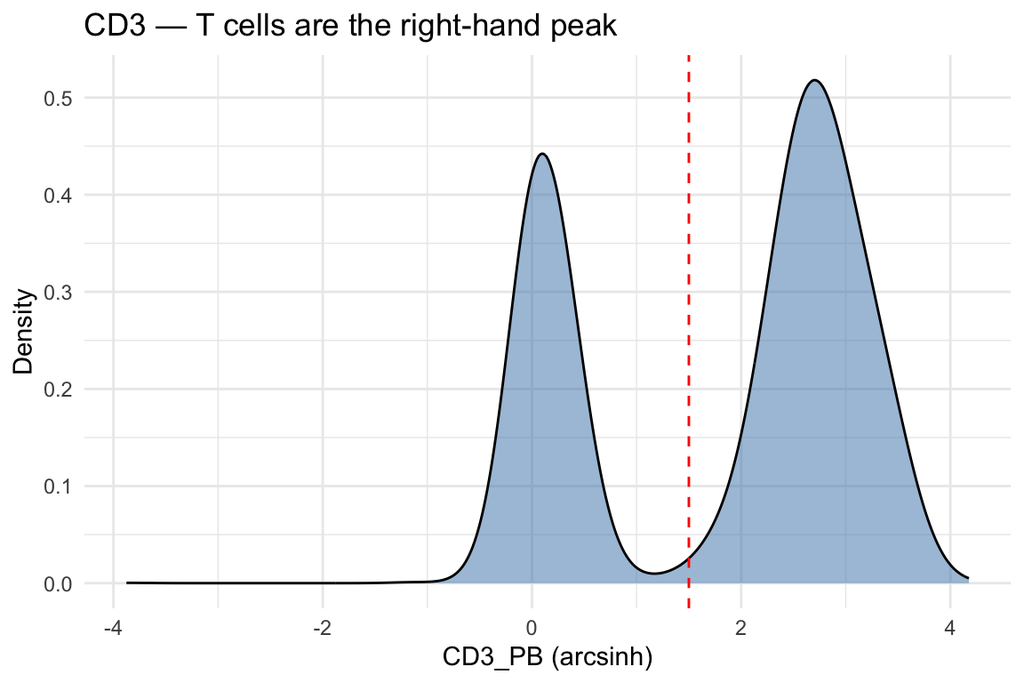

```r
df_live <- get_pop_df(gs, "live")

ggplot(df_live, aes(x = CD3_PB)) +
  geom_density(fill = "steelblue", alpha = 0.5) +
  geom_vline(xintercept = 1.5, color = "red", linetype = "dashed") +
  theme_minimal(base_size = 11) +
  labs(title = "CD3 — T cells are the right-hand peak",
       x = "CD3_PB (arcsinh)", y = "Density")
```

```r
tcell_gate <- rectangleGate(
  filterId  = "T_cells",
  "CD3_PB"  = c(1.5, Inf)
)
gs_pop_add(gs, tcell_gate, parent = "live")
```

```
## [1] 5
```

```r
recompute(gs)
```

```
## done!
```

```r
gs_pop_get_stats(gs, nodes = gs_get_pop_paths(gs), type = "count")
```

```
##    sample                               pop count
##    <char>                            <char> <num>
## 1:   PBMC                              root  6139
## 2:   PBMC                       /leukocytes  5748
## 3:   PBMC              /leukocytes/singlets  5745
## 4:   PBMC         /leukocytes/singlets/live  5555
## 5:   PBMC /leukocytes/singlets/live/T_cells  3559
```

Large drops between steps are worth investigating. A very small live cell count relative to singlets can indicate a sample quality issue; a very small T cell count may reflect biology (immunosuppressed patient) or a staining problem.

```r
unlink("data/processed/PBMC_gs_gated", recursive = TRUE)
save_gs(gs, path = "data/processed/PBMC_gs_gated")
```

```
## Done
## To reload it, use 'load_gs' function
```

```r
cat("Gated GatingSet saved\n")
```

```
## Gated GatingSet saved
```

← Prev: Unmixing & Transformation Next: Dimensionality Reduction →